# Markdowm 사용방법

Lim Wonki

2019. 06. 10.

[코드 출처](https://heropy.blog/2017/09/30/markdown): Heropy Tech’s MarkDown 사용법 총정리  
[참고자료](https://sergeswin.com/1013)  
[Markdown-guide](https://about.gitlab.com/handbook/product/technical-writing/markdown-guide/)

### **마크다운의 장점**

1. 문법이 쉽다.
2. 관리가 쉽다.
3. 지원 가능한 플랫폼과 프로그램이 다양하다.

### **마크다운의 단점**

1. 표준이 없어 사용자마다 문법이 상이할 수 있다.
2. 모든 HTML 마크업을 대신하지 못한다.

### **마크다운의 사용**

1. 메모장부터 전용 에디터까지 많은 곳에서 활용할 수 있다.
2. 문법이 쉽기 때문에 꼭 전용 에디터를 사용할 필요는 없지만,
3. 마크다운 코드의 하이라이트 효과를 원한다면 전용 에디터가 좋을 수 있다.

### **마크다운 문법(Syntax)**

### **제목(Header)**

`<h1>`부터 `<h6>`까지 제목을 표현할 수 있다

```
# 제목 1
## 제목 2
### 제목 3
#### 제목 4
##### 제목 5
###### 제목 6
```

### **강조 (Emphasis)**

각각 `<em>`, `<strong>`, `<del>`태그로 변환된다.

```
 이탤릭체는 *별표*를 사용하세요.
 두껍게는 **별표 2개**를 사용하세요
 두꺼운 이탤릭체는 ***별표 3개***를 사용하세요
 취소선은 ~~물결표시"~"~~를 사용하세요.
 <u>밑줄</u>은 `<u></u>`를 사용하세요.
 HTML에서 <hr>태그로 표현되는 수평선은 마크다운에서는 *** 또는 --- 또는 ___ 로 표현됩니다.
```

### **수평선(Horizontal Rule)**

HTML에서 `<hr>`태그로 표현되는 수평선은 마크다운에서는 `***`로 표현된다.

### **목록(List)**

`<ol>`,`<ul>`목록 태그로 변환된다.

```
  1. 순서가 필요한 목록

  1. 순서가 필요한 목록

      - 순서가 필요하지 않은 목록(서브)

      + 순서가 필요하지 않은 목록(서브)

  1. 순서가 필요한 목록

      3.1) 순서가 필요한 목록(서브)

      3.2) 순서가 필요한 목록(서브)

  1. 순서가 필요한 목록

  - 순서가 필요하지 않은 목록에 사용가능한 기호

      - 대쉬(hyphen)

      * 별표(asterisks)

      + 더하기(plus sign)
```

1. 순서가 필요한 목록
2. 순서가 필요한 목록
   - 순서가 필요하지 않은 목록(서브)
   - 순서가 필요하지 않은 목록(서브)
3. 순서가 필요한 목록

   3.1) 순서가 필요한 목록(서브)

   3.2) 순서가 필요한 목록(서브)
4. 순서가 필요한 목록
- 순서가 필요하지 않은 목록에 사용가능한 기호
  - 대쉬(hyphen)
  - 별표(asterisks)
  - 더하기(plus sign)

### **링크(Link)**

`<a>`로 변환된다.

```
[GOOGLE](https://google.com)

[NAVER](https://naver.com)

구글 홈페이지: https://google.com

네이버 홈페이지: <https://naver.com>
```

[GOOGLE](https://google.com)

[NAVER](https://naver.com)

다음과 같이 문서 내 일반 URL이나 꺽쇠 괄호(`< >`, Angle Brackets)안의 URL은 자동으로 링크를 사용한다.

구글 홈페이지: https://google.com

네이버 홈페이지: https://naver.com

### **이미지(Images)**

`<img>`로 변환된다.

링크와 비슷하지만 앞에 `!`가 붙는다.

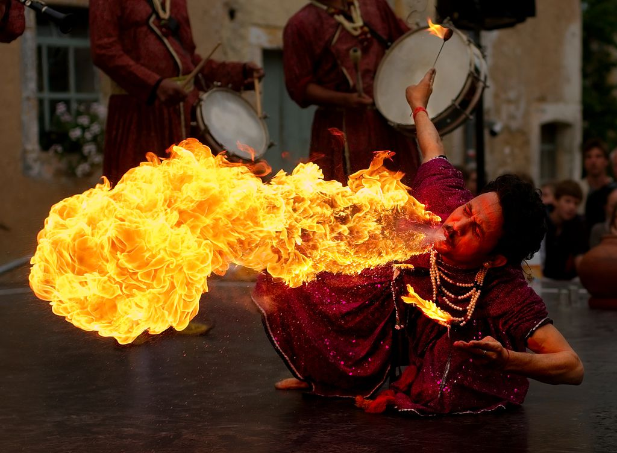

```
  ![불쇼 사진](http://www.gstatic.com/webp/gallery/5.jpg "링크 설명(title)을 작성하세요.")

  ![Kayak][logo]

  [logo]: http://www.gstatic.com/webp/gallery/2.jpg "To go kayaking."
```

### **코드(Code) 강조**

`<pre>`, `<code>`로 변환됩니다.

숫자 1번키 왼쪽에 있는 `'`(Grave)를 통해 감싼다.

#### **인라인(Inline) 코드 강조**

```
  `background`혹은 `background-image` 속성으로 요소에 배경 이미지를 삽입할 수 있다.
```

`background`혹은 `background-image` 속성으로 요소에 배경 이미지를 삽입할 수 있다.

#### **블록(Block) 코드 강조**

`'`(Grave)를 3번 이상 입력하고 코드 종류를 적은 후 감싼다.

```html
<a href="https://www.google.co.kr/" target="_blank">GOOGLE</a>
```

```css
.list > li {
  position: absolute;
  top: 40px;
}
```

```javascript
function func() {
  var a = 'AAA';
  return a;
}
```

```bash
$ vim ./~zshrc
```

```python
s = "Python syntax highlighting"
print s
```

```
No language indicated, so no syntax highlighting.
But let's throw in a tag.
```

### **표(Table)**

`<table>`태그로 변환된다.  
헤더 셀을 구분할 때 3개 이상의 `-`(hyphen/dash) 기호가 필요하다.  
헤더 셀을 구분하면서 `:`(Colons) 기호로 셀(열/칸) 안에 내용을 정렬할 수 있다.  
가장 좌측과 가장 우측에 있는 `|`(vertical bar) 기호는 생략이 가능하다.

```
값 | 의미 | 기본값
---|:---:|---:
`static` | 유형(기준) 없음 / 배치 불가능 | `static`
`relative` | 요소 **자신**을 기준으로 배치 |
`absolute` | 위치 상 **_부모_(조상)요소**를 기준으로 배치 |
`fixed` | **브라우저 창**을 기준으로 배치 |
```

| 값 | 의미 | 기본값 |
| --- | --- | --- |
| `static` | 유형(기준) 없음 / 배치 불가능 | `static` |
| `relative` | 요소 **자신**을 기준으로 배치 |  |
| `absolute` | 위치 상 *부모*(조상)요소를 기준으로 배치 |  |
| `fixed` | **브라우저 창**을 기준으로 배치 |  |

### **인용문(BlockQuote)**

`<blockquote>`태그로 변환된다.

```
  인용문(blockQuote)

> 남의 말이나 글에서 직접 또는 간접으로 따온 문장.
> _(네이버 국어 사전)_

  BREAK!

> 인용문을 작성하세요! <br>
>> 중첩된 인용문(nested blockquote)을 만들 수 있습니다. <br>
>>> 중중첩된 인용문 1 <br>
>>> 중중첩된 인용문 2 <br>
>>> 중중첩된 인용문 3 <br>
```

##### 인용문(blockQuote)

> 남의 말이나 글에서 직접 또는 간접으로 따온 문장. *(네이버 국어 사전)*

##### BREAK!

> 인용문을 작성하세요!  
> > 중첩된 인용문(nested blockquote)을 만들 수 있습니다.  
> >> 중중첩된 인용문 1  
> >> 중중첩된 인용문 2  
> >> 중중첩된 인용문 3

## **R 에서 코드 실행결과 다루기**

#### **실행코드와 결과 보여주기**

```r
summary(iris)
```

```
##   Sepal.Length    Sepal.Width     Petal.Length    Petal.Width
##  Min.   :4.300   Min.   :2.000   Min.   :1.000   Min.   :0.100
##  1st Qu.:5.100   1st Qu.:2.800   1st Qu.:1.600   1st Qu.:0.300
##  Median :5.800   Median :3.000   Median :4.350   Median :1.300
##  Mean   :5.843   Mean   :3.057   Mean   :3.758   Mean   :1.199
##  3rd Qu.:6.400   3rd Qu.:3.300   3rd Qu.:5.100   3rd Qu.:1.800
##  Max.   :7.900   Max.   :4.400   Max.   :6.900   Max.   :2.500
##        Species
##  setosa    :50
##  versicolor:50
##  virginica :50
##
##
##
```

#### **실행코드 없이 결과만 보여주기 {r, echo=FALSE}**

```
##   Sepal.Length    Sepal.Width     Petal.Length    Petal.Width
##  Min.   :4.300   Min.   :2.000   Min.   :1.000   Min.   :0.100
##  1st Qu.:5.100   1st Qu.:2.800   1st Qu.:1.600   1st Qu.:0.300
##  Median :5.800   Median :3.000   Median :4.350   Median :1.300
##  Mean   :5.843   Mean   :3.057   Mean   :3.758   Mean   :1.199
##  3rd Qu.:6.400   3rd Qu.:3.300   3rd Qu.:5.100   3rd Qu.:1.800
##  Max.   :7.900   Max.   :4.400   Max.   :6.900   Max.   :2.500
##        Species
##  setosa    :50
##  versicolor:50
##  virginica :50
##
##
##
```

#### **결과 없이 코드드만 보여주기 {r, eval=FALSE}**

```r
summary(iris)
```

#### **테이블(Table) 출력 : ‘asis’ 옵션 // TURE = 테두리 없이 출력**

```r
summary(iris)
```

```
##   Sepal.Length    Sepal.Width     Petal.Length    Petal.Width
##  Min.   :4.300   Min.   :2.000   Min.   :1.000   Min.   :0.100
##  1st Qu.:5.100   1st Qu.:2.800   1st Qu.:1.600   1st Qu.:0.300
##  Median :5.800   Median :3.000   Median :4.350   Median :1.300
##  Mean   :5.843   Mean   :3.057   Mean   :3.758   Mean   :1.199
##  3rd Qu.:6.400   3rd Qu.:3.300   3rd Qu.:5.100   3rd Qu.:1.800
##  Max.   :7.900   Max.   :4.400   Max.   :6.900   Max.   :2.500
##        Species
##  setosa    :50
##  versicolor:50
##  virginica :50
##
##
##
```

```r
summary(iris)
```

Sepal.Length Sepal.Width Petal.Length Petal.Width  
Min. :4.300 Min. :2.000 Min. :1.000 Min. :0.100  
1st Qu.:5.100 1st Qu.:2.800 1st Qu.:1.600 1st Qu.:0.300  
Median :5.800 Median :3.000 Median :4.350 Median :1.300  
Mean :5.843 Mean :3.057 Mean :3.758 Mean :1.199  
3rd Qu.:6.400 3rd Qu.:3.300 3rd Qu.:5.100 3rd Qu.:1.800  
Max. :7.900 Max. :4.400 Max. :6.900 Max. :2.500  
Species  
setosa :50  
versicolor:50  
virginica :50

#### **인라인 코드 추가**

```
 R 코드 결과 추가 : iris의 dimension은 150, 5 입니다. <br>
 R 코드만 추가 : iris의 dimension은 `dim(iris)` 입니다.
```

R 코드 결과 추가 : iris의 dimension은 150, 5 입니다.  
R 코드만 추가 : iris의 dimension은 `dim(iris)` 입니다.

차이점은 `뒤에 r의 유무, “r”이 있어야 r 코드로 인식